# Variable Electricity Rate Analysis

```r
#library(rmarkdown)
library(tidyverse)
library(lubridate)
library(hms)
```

Import and examine PPL 15 minute net meter interval data

```r
hourly_ppl_pivot <- read_csv("ppl_15mins.csv")
(hourly_ppl_net <- hourly_ppl_pivot %>%
  filter(`Read Type` == "kWh Net") %>%
  arrange(desc(date)))
```

| date | Read Type | time | kWh |
| --- | --- | --- | --- |
| 2024-08-18 | kWh Net | 00:00:00 | 0.62 |
| 2024-08-18 | kWh Net | 00:15:00 | 0.38 |
| 2024-08-18 | kWh Net | 00:30:00 | 0.13 |
| 2024-08-18 | kWh Net | 00:45:00 | 0.09 |
| 2024-08-18 | kWh Net | 01:00:00 | 0.10 |
| 2024-08-18 | kWh Net | 01:15:00 | 0.10 |
| 2024-08-18 | kWh Net | 01:30:00 | 0.09 |
| 2024-08-18 | kWh Net | 01:45:00 | 0.34 |
| 2024-08-18 | kWh Net | 02:00:00 | 0.10 |
| 2024-08-18 | kWh Net | 02:15:00 | 0.11 |

[output cut: 990 more lines]

Load Enphase data

```r
full_hist <- read_csv("enphase_production.csv")
(hourly_production <- full_hist %>%
  rename(datetime = `Date/Time`, energy_produced_Wh = `Energy Produced (Wh)`) %>%
  mutate(datetime = as.POSIXct(datetime,format="%m/%d/%Y %H:%M",tz=Sys.timezone())) %>%
  mutate(date = date(datetime), time = as.hms(format(datetime, format = "%H:%M:%S")), month = month(datetime, label=TRUE), year = year(datetime), day = day(datetime), yday = yday(datetime), monthday = format(datetime, "%m-%d"), wday = wday(datetime, label=TRUE), equinox_day = (yday + 10) %% 365, equinox_group = floor((equinox_day+15)/30)*30) %>%
    arrange(desc(datetime))
)
```

| ...1 | datetime | energy_produced_Wh | date | time | month | year | day | yday | monthday | wday | equinox_day | equinox_group |
| --- | --- | --- | --- | --- | --- | --- | --- | --- | --- | --- | --- | --- |
| 82368 | 2024-08-19 23:45:00 | 0 | 2024-08-19 | 23:45:00 | Aug | 2024 | 19 | 232 | 08-19 | Mon | 242 | 240 |
| 82367 | 2024-08-19 23:30:00 | 0 | 2024-08-19 | 23:30:00 | Aug | 2024 | 19 | 232 | 08-19 | Mon | 242 | 240 |
| 82366 | 2024-08-19 23:15:00 | 0 | 2024-08-19 | 23:15:00 | Aug | 2024 | 19 | 232 | 08-19 | Mon | 242 | 240 |
| 82365 | 2024-08-19 23:00:00 | 0 | 2024-08-19 | 23:00:00 | Aug | 2024 | 19 | 232 | 08-19 | Mon | 242 | 240 |
| 82364 | 2024-08-19 22:45:00 | 0 | 2024-08-19 | 22:45:00 | Aug | 2024 | 19 | 232 | 08-19 | Mon | 242 | 240 |
| 82363 | 2024-08-19 22:30:00 | 0 | 2024-08-19 | 22:30:00 | Aug | 2024 | 19 | 232 | 08-19 | Mon | 242 | 240 |
| 82362 | 2024-08-19 22:15:00 | 0 | 2024-08-19 | 22:15:00 | Aug | 2024 | 19 | 232 | 08-19 | Mon | 242 | 240 |
| 82361 | 2024-08-19 22:00:00 | 0 | 2024-08-19 | 22:00:00 | Aug | 2024 | 19 | 232 | 08-19 | Mon | 242 | 240 |
| 82360 | 2024-08-19 21:45:00 | 0 | 2024-08-19 | 21:45:00 | Aug | 2024 | 19 | 232 | 08-19 | Mon | 242 | 240 |
| 82359 | 2024-08-19 21:30:00 | 0 | 2024-08-19 | 21:30:00 | Aug | 2024 | 19 | 232 | 08-19 | Mon | 242 | 240 |

[output cut: 990 more lines]

Net + Produced = Consumed Start and End Dates of electricity data

```r
(hourly_electricity <- hourly_ppl_net %>%
    inner_join(hourly_production, by = join_by(date,time))  %>%
    mutate(consumed_kWh = kWh + energy_produced_Wh/1000, produced_kWh = energy_produced_Wh/1000)  %>%
    rename(net_kWh = kWh) %>%
    select(datetime, date, time, net_kWh, produced_kWh, consumed_kWh) %>%
    arrange(desc(datetime)))
```

| datetime | date | time | net_kWh | produced_kWh | consumed_kWh |
| --- | --- | --- | --- | --- | --- |
| 2024-08-18 23:45:00 | 2024-08-18 | 23:45:00 | 0.15 | 0.000 | 0.150 |
| 2024-08-18 23:30:00 | 2024-08-18 | 23:30:00 | 0.13 | 0.000 | 0.130 |
| 2024-08-18 23:15:00 | 2024-08-18 | 23:15:00 | 0.14 | 0.000 | 0.140 |
| 2024-08-18 23:00:00 | 2024-08-18 | 23:00:00 | 0.27 | 0.000 | 0.270 |
| 2024-08-18 22:45:00 | 2024-08-18 | 22:45:00 | 0.42 | 0.000 | 0.420 |
| 2024-08-18 22:30:00 | 2024-08-18 | 22:30:00 | 0.12 | 0.000 | 0.120 |
| 2024-08-18 22:15:00 | 2024-08-18 | 22:15:00 | 0.23 | 0.000 | 0.230 |
| 2024-08-18 22:00:00 | 2024-08-18 | 22:00:00 | 0.49 | 0.000 | 0.490 |
| 2024-08-18 21:45:00 | 2024-08-18 | 21:45:00 | 0.13 | 0.000 | 0.130 |
| 2024-08-18 21:30:00 | 2024-08-18 | 21:30:00 | 0.34 | 0.000 | 0.340 |

[output cut: 990 more lines]

```r
hourly_electricity %>%
  summarize(min(date), max(date))
```

| min(date) | max(date) |
| --- | --- |
| 2022-04-15 | 2024-08-18 |

```r
NA
```

Cost of fixed rate electricity over the full period.

```r
fixed_rate <- 0.1004 + 0.04727 #PA average electricity rate, supply + delivery charges combined

hourly_electricity %>%
  mutate(net_fixed = net_kWh * fixed_rate, consumed_fixed = consumed_kWh * fixed_rate) %>%
  #group_by(year(date), month(date)) %>%
  summarize(net_fixed = sum(net_fixed), consumed_fixed = sum(consumed_fixed))
```

| net_fixed | consumed_fixed |
| --- | --- |
| -1006.845 | 5429.525 |

```r
NA
```

Time of Use rate cost over the full period

```r
#https://www.pplelectric.com/my-account/shop-for-electricity/time-of-use-plan/tou-enrollment
peak_rate <- 0.12936 + 0.04727
off_peak_rate <- 0.09319 + 0.04727

#add holidays to off_peak
  # New Year's Day
  # Presidents Day
  # Good Friday
  # Memorial Day
  # Independence Day
  # Labor Day
  # Thanksgiving Day
  # Day after Thanksgiving
  # Christmas Eve
  # Christmas Day

hourly_electricity %>%
  mutate(tou_rate = case_when(wday(datetime) %in% c(1,7) ~ off_peak_rate, #weekends
                                   hour(datetime) >= 14 & hour(datetime) < 18 & month(datetime) %in% c(6,7,8,9,10,11) ~ peak_rate, #JuneToNovPeak
                                   hour(datetime) >= 16 & hour(datetime) < 20 & month(datetime) %in% c(12,1,2,3,4,5) ~ peak_rate, #DecToMayPeak
                                   .default = off_peak_rate
                                   )
         ) %>%
  #group_by(year(date), month(date)) %>%
  summarize(net_tou_cost = sum(net_kWh*tou_rate), consumed_tou_cost = sum(consumed_kWh*tou_rate))
```

| net_tou_cost | consumed_tou_cost |
| --- | --- |
| -1082.989 | 5337.617 |

```r
NA
NA
```

Somewhat better to shift to TOU in both cases (with or without solar).

What if we shifted the EV charging load? - Detect EV charging load - Give it the lower rate

Load Emporia charging 15 minute interval data

```r
min15_2023 <- read_csv("FA1BE4-Emporia_Garage-15MIN_20230609_20231231.csv", show_col_types = FALSE) %>%
                mutate(`Date/Time` = as.POSIXct(`Time Bucket (America/New_York)`,format="%m/%d/%Y %H:%M",tz=Sys.timezone()))
min15_2024 <- read_csv("FA1BE4-Emporia_Garage-15MIN_20240101_20240613.csv", show_col_types = FALSE) %>%
                mutate(`Date/Time` = as.POSIXct(`Time Bucket (America/New_York)`,format="%m/%d/%Y %H:%M",tz=Sys.timezone())) %>%
                filter(`Date/Time` < as.POSIXct('06/11/2024 00:00',format="%m/%d/%Y %H:%M",tz=Sys.timezone()) )
min15_2024_2 <- read_csv("FA1BE4-Emporia_Garage-15MIN_20240611_20240819.csv", show_col_types = FALSE) %>%
                mutate(`Date/Time` = as.POSIXct(`Time Bucket (America/New_York)`,format="%m/%d/%Y %H:%M",tz=Sys.timezone())) %>%
                filter(`Date/Time` < as.POSIXct('08/20/2024 00:00',format="%m/%d/%Y %H:%M",tz=Sys.timezone()) )

# min15_2023 <- read_csv("FA1BE4-Emporia_Garage-15MIN_20230609_20231231.csv", show_col_types = FALSE)
# min15_2024 <- read_csv("FA1BE4-Emporia_Garage-15MIN_20240101_20240613.csv", show_col_types = FALSE)
# min15_2024_2 <- read_csv("FA1BE4-Emporia_Garage-15MIN_20240611_20240819.csv", show_col_types = FALSE)

min15_charging <- rbind(min15_2023,min15_2024)
min15_charging <- rbind(min15_charging,min15_2024_2)

#min15_charging <- rbind(min15_2024,list(min15_2024,min15_2024_2))

#change data types
min15_charging <- min15_charging %>%
  rename(datetime = `Time Bucket (America/New_York)`, kW = `Emporia Garage-EV (kWatts)`) %>%
  #mutate(datetime = as_datetime(datetime, tz = 'America/New_York'))
  #mutate(datetime = as.POSIXct(datetime,format="%m/%d/%Y %H:%M:%S",tz='America/New_York'))
  mutate(datetime = mdy_hms(datetime, tz = 'America/New_York')) %>%
  mutate(solar_year = factor(case_when(
                        datetime < as.POSIXct('04/16/2022 00:00',format="%m/%d/%Y %H:%M",tz=Sys.timezone()) ~ 0,
                        datetime >= as.POSIXct('04/16/2022 00:00',format="%m/%d/%Y %H:%M",tz=Sys.timezone())  &
                          datetime < as.POSIXct('04/16/2023 00:00',format="%m/%d/%Y %H:%M",tz=Sys.timezone()) ~ 1,
                        datetime >= as.POSIXct('04/16/2023 00:00',format="%m/%d/%Y %H:%M",tz=Sys.timezone())  &
                          datetime < as.POSIXct('04/16/2024 00:00',format="%m/%d/%Y %H:%M",tz=Sys.timezone()) ~ 2,
                        TRUE ~ 3)
         )) %>%
  arrange(desc(datetime))

min15_charging <- min15_charging %>%
  mutate(date = date(datetime), time = as_hms(datetime)) %>%
  mutate(charging_kWh = kW/4) %>%
  select (-c(solar_year,`Date/Time`,kW))

min15_charging
```

| datetime | date | time | charging_kWh |
| --- | --- | --- | --- |
| 2024-08-19 23:45:00 | 2024-08-19 | 23:45:00 | 0.000000 |
| 2024-08-19 23:30:00 | 2024-08-19 | 23:30:00 | 0.000000 |
| 2024-08-19 23:15:00 | 2024-08-19 | 23:15:00 | 0.000000 |
| 2024-08-19 23:00:00 | 2024-08-19 | 23:00:00 | 0.000000 |
| 2024-08-19 22:45:00 | 2024-08-19 | 22:45:00 | 0.000000 |
| 2024-08-19 22:30:00 | 2024-08-19 | 22:30:00 | 0.000000 |
| 2024-08-19 22:15:00 | 2024-08-19 | 22:15:00 | 0.000000 |
| 2024-08-19 22:00:00 | 2024-08-19 | 22:00:00 | 0.000000 |
| 2024-08-19 21:45:00 | 2024-08-19 | 21:45:00 | 0.000000 |
| 2024-08-19 21:30:00 | 2024-08-19 | 21:30:00 | 0.000000 |

[output cut: 990 more lines]

Check date range for available hourly charging data

```r
min15_charging %>%
  summarize(min(datetime), max(datetime))
```

| min(datetime) | max(datetime) |
| --- | --- |
| 2023-06-09 20:15:00 | 2024-08-19 23:45:00 |

```r
min_datetime <- pull(min15_charging %>% summarize(min = min(datetime)))
max_datetime <- pull(min15_charging %>% summarize(max = max(datetime)))
```

Run fixed and variable rates on those dates Fixed rate cost on this date range.

```r
#Fixed rate

hourly_electricity %>%
  filter(between(date, min_datetime, max_datetime)) %>%
  arrange(desc(datetime))
```

| datetime | date | time | net_kWh | produced_kWh | consumed_kWh |
| --- | --- | --- | --- | --- | --- |
| 2024-08-18 23:45:00 | 2024-08-18 | 23:45:00 | 0.15 | 0.000 | 0.150 |
| 2024-08-18 23:30:00 | 2024-08-18 | 23:30:00 | 0.13 | 0.000 | 0.130 |
| 2024-08-18 23:15:00 | 2024-08-18 | 23:15:00 | 0.14 | 0.000 | 0.140 |
| 2024-08-18 23:00:00 | 2024-08-18 | 23:00:00 | 0.27 | 0.000 | 0.270 |
| 2024-08-18 22:45:00 | 2024-08-18 | 22:45:00 | 0.42 | 0.000 | 0.420 |
| 2024-08-18 22:30:00 | 2024-08-18 | 22:30:00 | 0.12 | 0.000 | 0.120 |
| 2024-08-18 22:15:00 | 2024-08-18 | 22:15:00 | 0.23 | 0.000 | 0.230 |
| 2024-08-18 22:00:00 | 2024-08-18 | 22:00:00 | 0.49 | 0.000 | 0.490 |
| 2024-08-18 21:45:00 | 2024-08-18 | 21:45:00 | 0.13 | 0.000 | 0.130 |
| 2024-08-18 21:30:00 | 2024-08-18 | 21:30:00 | 0.34 | 0.000 | 0.340 |

[output cut: 990 more lines]

```r
hourly_electricity %>%
  mutate(net_fixed_cost = net_kWh * fixed_rate, consumed_fixed_cost = consumed_kWh * fixed_rate) %>%
  filter(between(datetime, min_datetime, max_datetime)) %>%
  summarize(net_fixed_cost = sum(net_fixed_cost), consumed_fixed_cost = sum(consumed_fixed_cost))
```

| net_fixed_cost | consumed_fixed_cost |
| --- | --- |
| -522.6366 | 2664.593 |

```r
NA
```

TOU cost for this date range

```r
#variable rate
hourly_electricity %>%
  mutate(tou_rate = case_when(wday(datetime) %in% c(1,7) ~ off_peak_rate, #weekends
                                   hour(datetime) >= 14 & hour(datetime) < 18 & month(datetime) %in% c(6,7,8,9,10,11) ~ peak_rate, #JuneToNovPeak
                                   hour(datetime) >= 16 & hour(datetime) < 20 & month(datetime) %in% c(12,1,2,3,4,5) ~ peak_rate, #DecToMayPeak
                                   .default = off_peak_rate
                                   )
         ) %>%
  filter(between(datetime, min_datetime, max_datetime)) %>%
  summarize(net_tou_cost = sum(net_kWh*tou_rate), consumed_variable = sum(consumed_kWh*tou_rate))
```

| net_tou_cost | consumed_variable |
| --- | --- |
| -569.7609 | 2619.263 |

```r
NA
```

Shift EV charging to lower rate

[output not shown]

[output cut: 990 more lines]

Plot of energy usage by hour - Split by months

```r
by_month <- hourly_electricity %>%
  filter(between(datetime, min_datetime, max_datetime)) %>%
  mutate(month = as.factor(month(date))) %>%
  group_by(month, time) %>%
  summarize(n = n(), net_kWh = mean(net_kWh), produced_kWh = mean(produced_kWh), consumed_kWh = mean(consumed_kWh))
by_month %>%
  group_by(month) %>%
  summarize(net_kWh = sum(net_kWh), produced_kWh = sum(produced_kWh), consumed_kWh = sum(consumed_kWh)) %>%
  arrange(desc(net_kWh))
```

| month | net_kWh | produced_kWh | consumed_kWh |
| --- | --- | --- | --- |
| 1 | 48.125806 | 13.39658 | 61.52239 |
| 12 | 37.963548 | 16.04277 | 54.00632 |
| 2 | 23.904828 | 33.55793 | 57.46276 |
| 11 | 14.684430 | 33.33410 | 48.01853 |
| 3 | -4.925753 | 47.79052 | 42.86476 |
| 10 | -6.912581 | 40.32742 | 33.41484 |
| 9 | -17.489667 | 51.71753 | 34.22787 |
| 4 | -19.021667 | 55.37533 | 36.35367 |
| 7 | -25.100161 | 70.43958 | 45.33942 |
| 8 | -29.839388 | 59.25708 | 29.41769 |

[output cut: 2 more lines]

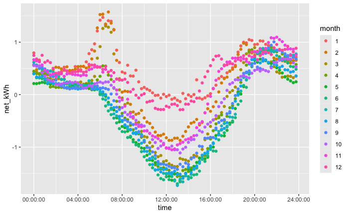

```r
ggplot(by_month, aes(time, net_kWh, color=month)) +
  geom_point()
```

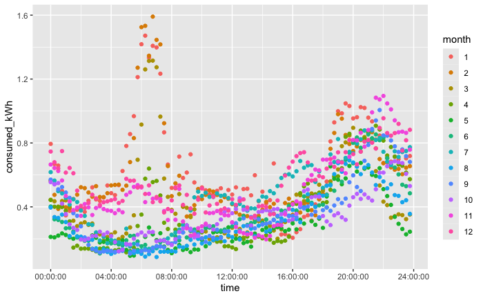

```r
ggplot(by_month, aes(time, consumed_kWh, color=month)) +
  geom_point()
```

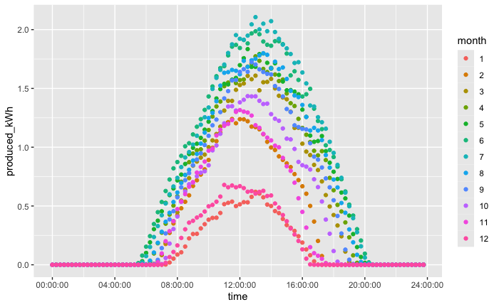

```r
ggplot(by_month, aes(time, produced_kWh, color=month)) +
  geom_point()
```

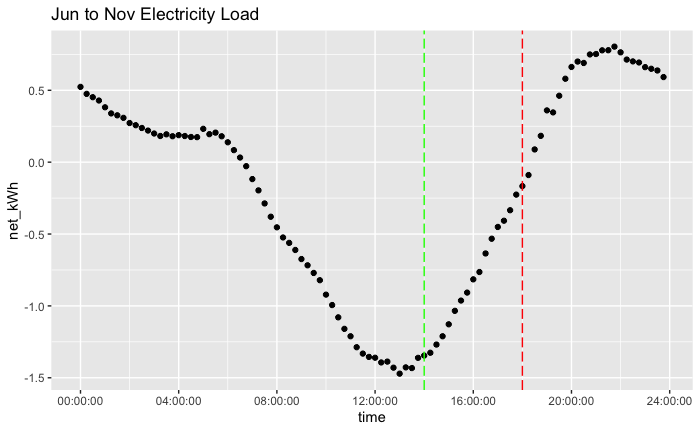

```r
jun_nov_electricity <- hourly_electricity %>%
  filter(between(datetime, min_datetime, max_datetime), month(date) %in% c(6,7,8,9,10,11)) %>%
  group_by(time) %>%
  summarize(n = n(), net_kWh = mean(net_kWh), produced_kWh = mean(produced_kWh), consumed_kWh = mean(consumed_kWh))

jun_nov_electricity <- hourly_electricity %>%
  filter(between(datetime, min_datetime, max_datetime), month(date) %in% c(6,7,8,9,10,11)) %>%
  group_by(time) %>%
  summarize(n = n(), net_kWh = mean(net_kWh), produced_kWh = mean(produced_kWh), consumed_kWh = mean(consumed_kWh))

ggplot(jun_nov_electricity, aes(time, net_kWh)) +
  geom_point() +
  geom_vline(xintercept = as_hms("14:00:00"), colour="green", linetype = "longdash") +
  geom_vline(xintercept = as_hms("18:00:00"), colour="red", linetype = "longdash") +
  ggtitle("Jun to Nov Electricity Load")
```

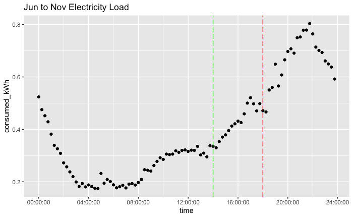

```r
ggplot(jun_nov_electricity, aes(time, consumed_kWh)) +
  geom_point() +
  geom_vline(xintercept = as_hms("14:00:00"), colour="green", linetype = "longdash") +
  geom_vline(xintercept = as_hms("18:00:00"), colour="red", linetype = "longdash") +
  ggtitle("Jun to Nov Electricity Load")
```

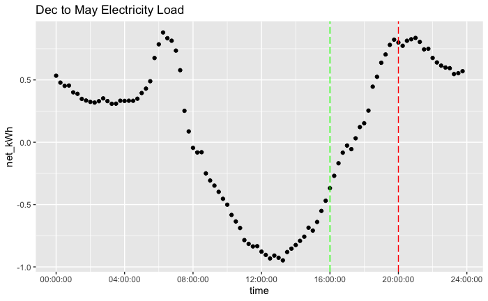

```r
dec_may_electricity <- hourly_electricity %>%
  filter(between(datetime, min_datetime, max_datetime), month(date) %in% c(12,1,2,3,4,5)) %>%
  group_by(time) %>%
  summarize(n = n(), net_kWh = mean(net_kWh), produced_kWh = mean(produced_kWh), consumed_kWh = mean(consumed_kWh))

ggplot(dec_may_electricity, aes(time, net_kWh)) +
  geom_point() +
  geom_vline(xintercept = as_hms("16:00:00"), colour="green", linetype = "longdash") +
  geom_vline(xintercept = as_hms("20:00:00"), colour="red", linetype = "longdash") +
  ggtitle("Dec to May Electricity Load")
```

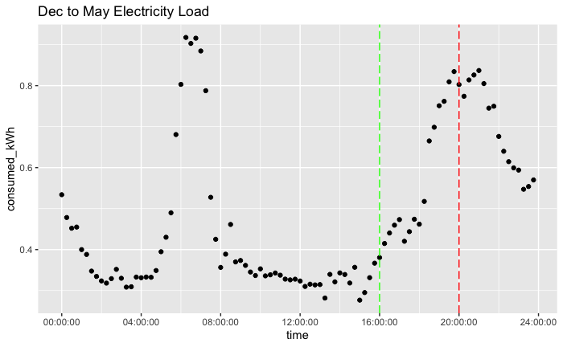

```r
ggplot(dec_may_electricity, aes(time, consumed_kWh)) +
  geom_point() +
  geom_vline(xintercept = as_hms("16:00:00"), colour="green", linetype = "longdash") +
  geom_vline(xintercept = as_hms("20:00:00"), colour="red", linetype = "longdash") +
  ggtitle("Dec to May Electricity Load")
```

```r
NA
NA
```

Load without charging

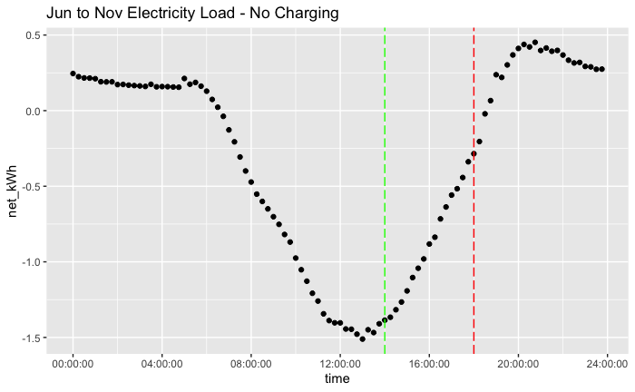

```r
jun_nov_electricity_no_charging <- min15_electricity_charging %>%
  filter(between(datetime, min_datetime, max_datetime), month(date) %in% c(6,7,8,9,10,11)) %>%
  mutate(period = "Jun to Nov") %>%
  group_by(period, time) %>%
  summarize(n = n(), net_kWh = mean(net_kWh_no_charging), produced_kWh = mean(produced_kWh), consumed_kWh = mean(consumed_kWh_no_charging))
ggplot(jun_nov_electricity_no_charging, aes(time, net_kWh)) +
  geom_point() +
  geom_vline(xintercept = as_hms("14:00:00"), colour="green", linetype = "longdash") +
  geom_vline(xintercept = as_hms("18:00:00"), colour="red", linetype = "longdash") +
  ggtitle("Jun to Nov Electricity Load - No Charging")
```

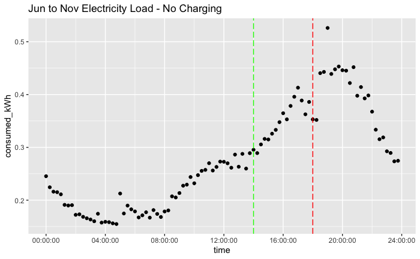

```r
ggplot(jun_nov_electricity_no_charging, aes(time, consumed_kWh)) +
  geom_point() +
  geom_vline(xintercept = as_hms("14:00:00"), colour="green", linetype = "longdash") +
  geom_vline(xintercept = as_hms("18:00:00"), colour="red", linetype = "longdash") +
  ggtitle("Jun to Nov Electricity Load - No Charging")
```

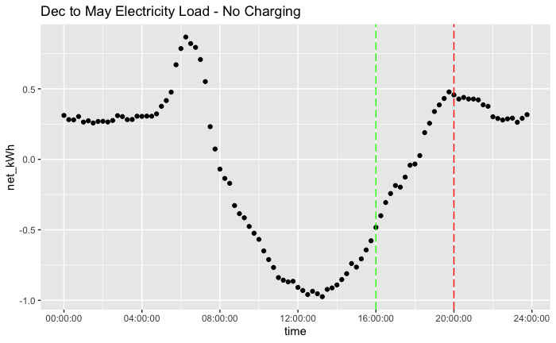

```r
dec_may_electricity_no_charging <- min15_electricity_charging %>%
  filter(between(datetime, min_datetime, max_datetime), month(date) %in% c(12,1,2,3,4,5)) %>%
  mutate(period = "Dec to May") %>%
  group_by(period, time) %>%
  summarize(n = n(), net_kWh = mean(net_kWh_no_charging), produced_kWh = mean(produced_kWh), consumed_kWh = mean(consumed_kWh_no_charging))
ggplot(dec_may_electricity_no_charging, aes(time, net_kWh)) +
  geom_point() +
  geom_vline(xintercept = as_hms("16:00:00"), colour="green", linetype = "longdash") +
  geom_vline(xintercept = as_hms("20:00:00"), colour="red", linetype = "longdash") +
  ggtitle("Dec to May Electricity Load - No Charging")
```

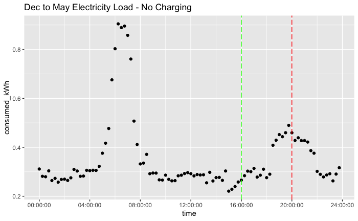

```r
ggplot(dec_may_electricity_no_charging, aes(time, consumed_kWh)) +
  geom_point() +
  geom_vline(xintercept = as_hms("16:00:00"), colour="green", linetype = "longdash") +
  geom_vline(xintercept = as_hms("20:00:00"), colour="red", linetype = "longdash") +
  ggtitle("Dec to May Electricity Load - No Charging")
```

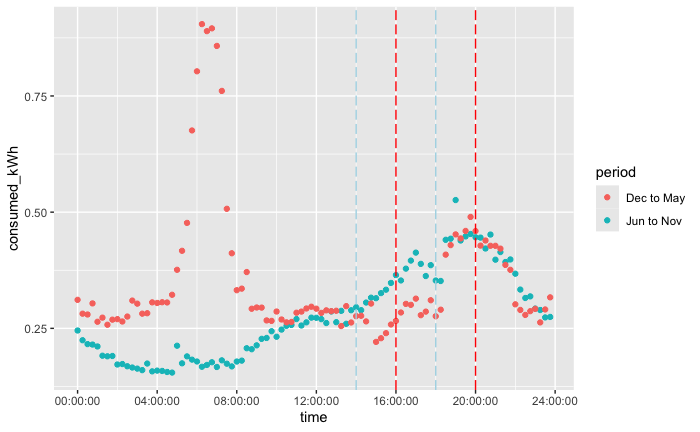

```r
electricity_no_charging_by_period <- rbind(jun_nov_electricity_no_charging, dec_may_electricity_no_charging)

ggplot(electricity_no_charging_by_period, aes(time, consumed_kWh, group=period, color=period)) +
  geom_point() +
  geom_vline(xintercept = as_hms("16:00:00"), color="red", linetype = "longdash") +
  geom_vline(xintercept = as_hms("20:00:00"), color="red", linetype = "longdash") +
  geom_vline(xintercept = as_hms("14:00:00"), color="light blue", linetype = "longdash") +
  geom_vline(xintercept = as_hms("18:00:00"), color="light blue", linetype = "longdash")
```

```r
min15_electricity_charging
```

| datetime | date | time | net_kWh | produced_kWh | consumed_kWh | datetime.y | charging_kWh | net_kWh_no_charging | consumed_kWh_no_charging |
| --- | --- | --- | --- | --- | --- | --- | --- | --- | --- |
| 2024-08-18 23:45:00 | 2024-08-18 | 23:45:00 | 0.15 | 0.000 | 0.150 | 2024-08-18 23:45:00 | 0.000000 | 0.150000 | 0.150000 |
| 2024-08-18 23:30:00 | 2024-08-18 | 23:30:00 | 0.13 | 0.000 | 0.130 | 2024-08-18 23:30:00 | 0.000000 | 0.130000 | 0.130000 |
| 2024-08-18 23:15:00 | 2024-08-18 | 23:15:00 | 0.14 | 0.000 | 0.140 | 2024-08-18 23:15:00 | 0.000000 | 0.140000 | 0.140000 |
| 2024-08-18 23:00:00 | 2024-08-18 | 23:00:00 | 0.27 | 0.000 | 0.270 | 2024-08-18 23:00:00 | 0.000000 | 0.270000 | 0.270000 |
| 2024-08-18 22:45:00 | 2024-08-18 | 22:45:00 | 0.42 | 0.000 | 0.420 | 2024-08-18 22:45:00 | 0.000000 | 0.420000 | 0.420000 |
| 2024-08-18 22:30:00 | 2024-08-18 | 22:30:00 | 0.12 | 0.000 | 0.120 | 2024-08-18 22:30:00 | 0.000000 | 0.120000 | 0.120000 |
| 2024-08-18 22:15:00 | 2024-08-18 | 22:15:00 | 0.23 | 0.000 | 0.230 | 2024-08-18 22:15:00 | 0.000000 | 0.230000 | 0.230000 |
| 2024-08-18 22:00:00 | 2024-08-18 | 22:00:00 | 0.49 | 0.000 | 0.490 | 2024-08-18 22:00:00 | 0.000000 | 0.490000 | 0.490000 |
| 2024-08-18 21:45:00 | 2024-08-18 | 21:45:00 | 0.13 | 0.000 | 0.130 | 2024-08-18 21:45:00 | 0.000000 | 0.130000 | 0.130000 |
| 2024-08-18 21:30:00 | 2024-08-18 | 21:30:00 | 0.34 | 0.000 | 0.340 | 2024-08-18 21:30:00 | 0.000000 | 0.340000 | 0.340000 |

[output cut: 990 more lines]

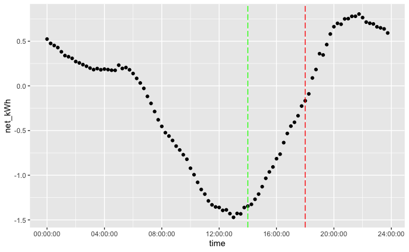

```r
jun_nov_electricity <- hourly_electricity %>%
  filter(between(datetime, min_datetime, max_datetime), month(date) %in% c(6,7,8,9,10,11)) %>%
  group_by(time) %>%
  summarize(n = n(), net_kWh = mean(net_kWh), produced_kWh = mean(produced_kWh), consumed_kWh = mean(consumed_kWh))

ggplot(jun_nov_electricity, aes(time, net_kWh)) +
  geom_point() +
  geom_vline(xintercept = as_hms("14:00:00"), colour="green", linetype = "longdash") +
  geom_vline(xintercept = as_hms("18:00:00"), colour="red", linetype = "longdash")
```

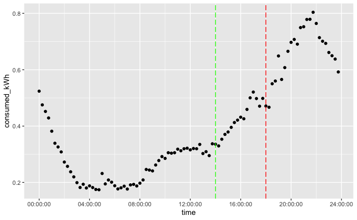

```r
ggplot(jun_nov_electricity, aes(time, consumed_kWh)) +
  geom_point() +
  geom_vline(xintercept = as_hms("14:00:00"), colour="green", linetype = "longdash") +
  geom_vline(xintercept = as_hms("18:00:00"), colour="red", linetype = "longdash")
```

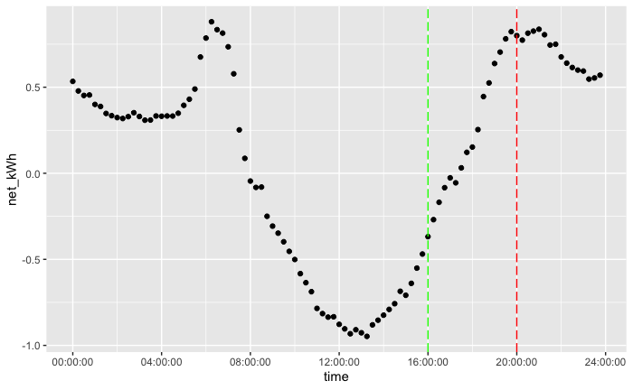

```r
dec_may_electricity <- hourly_electricity %>%
  filter(between(datetime, min_datetime, max_datetime), month(date) %in% c(12,1,2,3,4,5)) %>%
  group_by(time) %>%
  summarize(n = n(), net_kWh = mean(net_kWh), produced_kWh = mean(produced_kWh), consumed_kWh = mean(consumed_kWh))

ggplot(dec_may_electricity, aes(time, net_kWh)) +
  geom_point() +
  geom_vline(xintercept = as_hms("16:00:00"), colour="green", linetype = "longdash") +
  geom_vline(xintercept = as_hms("20:00:00"), colour="red", linetype = "longdash")
```

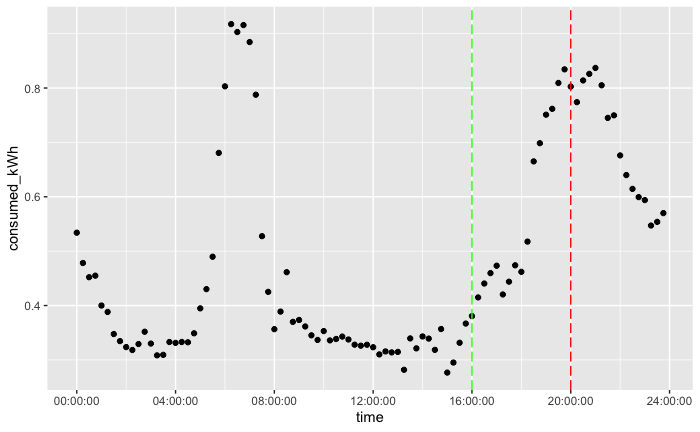

```r
ggplot(dec_may_electricity, aes(time, consumed_kWh)) +
  geom_point() +
  geom_vline(xintercept = as_hms("16:00:00"), colour="green", linetype = "longdash") +
  geom_vline(xintercept = as_hms("20:00:00"), colour="red", linetype = "longdash")
```

Plot of peak/off peak energy usage (stacked bar chart?) - Same plot with shifted load - Split by months

On peak vs off peak kWh by day/month

Charging by time of day? Winter vs. summer?

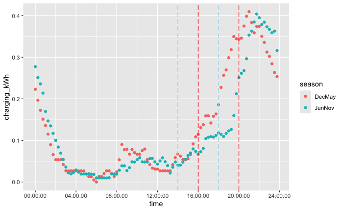

```r
seasonal_charging_times <- min15_electricity_charging %>%
  mutate(season = case_when(month(date) %in% c(6,7,8,9,10,11) ~ 'JunNov',
                            .default = 'DecMay')) %>%
  group_by(season, time) %>%
  summarize(charging_kWh = mean(charging_kWh))
ggplot(seasonal_charging_times, aes(time, charging_kWh, group=season, color=season)) +
  geom_point() +
  geom_vline(xintercept = as_hms("16:00:00"), color="red", linetype = "longdash") +
  geom_vline(xintercept = as_hms("20:00:00"), color="red", linetype = "longdash") +
  geom_vline(xintercept = as_hms("14:00:00"), color="light blue", linetype = "longdash") +
  geom_vline(xintercept = as_hms("18:00:00"), color="light blue", linetype = "longdash")
```

Plot of my average energy usage in “summer” vs. “winter”

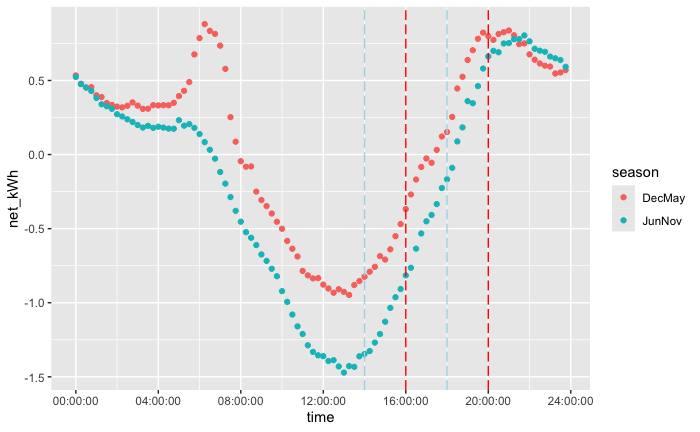

```r
seasonal_electricity <- hourly_electricity %>%
  filter(between(datetime, min_datetime, max_datetime)) %>%
  mutate(season = case_when(month(date) %in% c(6,7,8,9,10,11) ~ 'JunNov',
                            .default = 'DecMay')) %>%
  group_by(season, time) %>%
  summarize(n = n(), net_kWh = mean(net_kWh), produced_kWh = mean(produced_kWh), consumed_kWh = mean(consumed_kWh))
ggplot(seasonal_electricity, aes(time, net_kWh, group=season, color=season)) +
  geom_point() +
  geom_vline(xintercept = as_hms("16:00:00"), color="red", linetype = "longdash") +
  geom_vline(xintercept = as_hms("20:00:00"), color="red", linetype = "longdash") +
  geom_vline(xintercept = as_hms("14:00:00"), color="light blue", linetype = "longdash") +
  geom_vline(xintercept = as_hms("18:00:00"), color="light blue", linetype = "longdash")
```

```r
NA
```

plot of energy cost by day on each plan. - Total by month

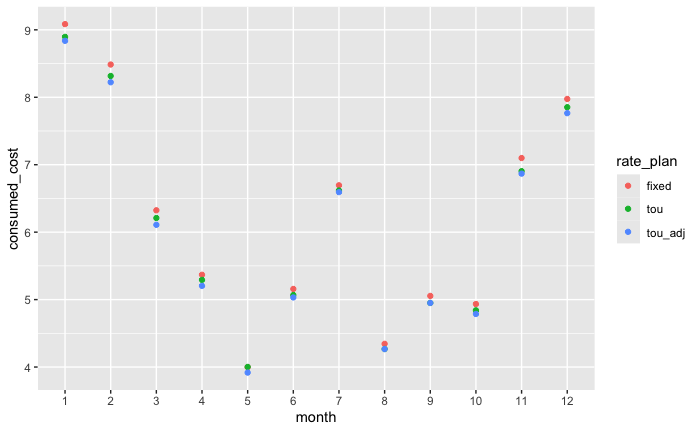